# question_4

### How dependent are the decision boundaries on the initial values of the weights? What do you see for each of the datasets when the initial weights are changed, and why?

If we initialize all weights with zeros then every hidden unit will get zero independent of the input. So, when all the hidden neurons have zero weights, then they get same gradient and updataion is also same, This only effects scale not direction. No matter what was the input - if all weights are the same, all units in hidden layer will be the same too.

### Compare the final decision boundary in each of the above datasets against the decision boundary obtained using a SVM and logistic regression. What differences do you see and why?

### Logistic Regression

It makes decision boundary based on logistic functions which is mainly probabilistic. While logistic regression the one that minimizes the cross-entropy loss.

### SVM

SVM tries makes decision boundary that reduces the risk of error on the test data. It tries to find a decision boundary that has the same distance from the boundary points of both classes. Decision boundary has maximal margin from both classes. SVM is geometrically motivated rather than statistically.

```python
from sklearn.datasets.samples_generator import make_blobs
from sklearn.datasets import make_moons
from matplotlib import pyplot as plt
from sklearn.datasets import make_circles
import pandas as pd
import numpy as np
import sklearn
```

## Function to plot graph based on weight ans bais

```python
def plotGraph(weight,bais,size,df,x):


    y = np.multiply((-weight[0]/weight[1]),x)-(bais/weight[1])

    colors = {-1:'red', 1:'blue'}
    fig, ax = plt.subplots()
    grouped = df.groupby('label')

    for key, group in grouped:
        group.plot(ax=ax, kind='scatter', x='x', y='y', label=key, color=colors[key])

    plt.plot(x,y)
    plt.show()
```

# Perceptron algorithm

```python
def perceptron(df,X,y,weight,bais,size=12,threshold=10):
    x  = np.random.randint(-10,10, size=(size))
    learning_rate = 0.01
    j = 0
    while(j!=threshold):
        j+=1
        for inputs,label in zip(X,y):
            yDash = np.dot(weight,inputs)+bais
            if yDash > 0:
                yDash = 1.0
            else:
                yDash = -1.0
            if yDash!=label:
                weight = weight + inputs*learning_rate*(label)
                bais = bais + learning_rate*(label)
        print("Iteration : ",j," Weights : ",weight, " bais : ",bais)
        plotGraph(weight,bais,size,df,x)
    return weight,bais
def predict(inputs,weight,bais):
    pred = np.dot(weight,inputs)+bais
    if pred <= 0:
        return 0
    else:
        return 1
```

# Linear Dataset 1

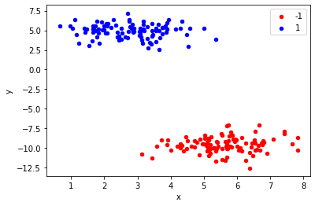

```python
# # generate 2d classification dataset
X, y = make_blobs(n_samples=200, centers=2, n_features=2,shuffle=True,random_state=10)
# # scatter plot, dots colored by class value
y[y==0] = -1
df_Linear = pd.DataFrame(dict(x=X[:,0], y=X[:,1], label=y))
#df.to_csv('./dataset/LinearDataset.csv',sep="\t",index=None)
#df = pd.read_csv('./dataset/LinearDataset.csv',sep='\t')
colors = {-1:'red', 1:'blue'}
fig, ax = plt.subplots()
grouped = df_Linear.groupby('label')

for key, group in grouped:
    group.plot(ax=ax, kind='scatter', x='x', y='y', label=key, color=colors[key])
plt.show()
```

```python
X = df_Linear.values
y = X[:,-1]
X = X[:,:2]
# y[y==0] = -1
learning_rate = 0.01
weight = np.zeros(2)

bais = 0

weight,bais = perceptron(df_Linear,X,y,weight,bais,12)
# i=10
# print(weight,bais)
# print(predict(X[i],weight,bais))
# print(y[i])
```

[output not shown]

```
Iteration :  1  Weights :  [0.03686949 0.0400588 ]  bais :  0.01
```

```
Iteration :  2  Weights :  [0.03686949 0.0400588 ]  bais :  0.01
```

```
Iteration :  3  Weights :  [0.03686949 0.0400588 ]  bais :  0.01
```

```
Iteration :  4  Weights :  [0.03686949 0.0400588 ]  bais :  0.01
```

```
Iteration :  5  Weights :  [0.03686949 0.0400588 ]  bais :  0.01
```

```
Iteration :  6  Weights :  [0.03686949 0.0400588 ]  bais :  0.01
```

```
Iteration :  7  Weights :  [0.03686949 0.0400588 ]  bais :  0.01
```

```
Iteration :  8  Weights :  [0.03686949 0.0400588 ]  bais :  0.01
```

```
Iteration :  9  Weights :  [0.03686949 0.0400588 ]  bais :  0.01
```

```
Iteration :  10  Weights :  [0.03686949 0.0400588 ]  bais :  0.01
```

# Linear dataset 2

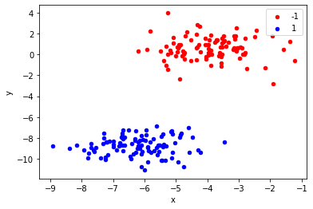

```python
# # generate 2d classification dataset
X, y = make_blobs(n_samples=200, centers=2, n_features=2,shuffle=True,random_state=17)
# # scatter plot, dots colored by class value
y[y==0] = -1
df_Linear1 = pd.DataFrame(dict(x=X[:,0], y=X[:,1], label=y))

colors = {-1:'red', 1:'blue'}
fig, ax = plt.subplots()
grouped = df_Linear1.groupby('label')

for key, group in grouped:
    group.plot(ax=ax, kind='scatter', x='x', y='y', label=key, color=colors[key])
plt.show()
```

```
Iteration :  1  Weights :  [ 0.09905862 -0.12469966]  bais :  -0.05
```

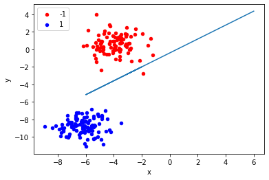

```
Iteration :  2  Weights :  [ 0.06828673 -0.1668356 ]  bais :  -0.060000000000000005
```

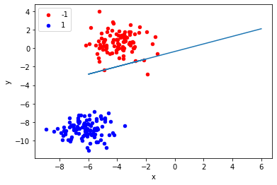

```
Iteration :  3  Weights :  [ 0.08728356 -0.13895364]  bais :  -0.07
```

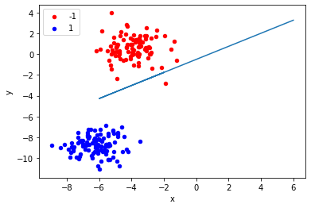

```
Iteration :  4  Weights :  [ 0.10166683 -0.1675965 ]  bais :  -0.09
```

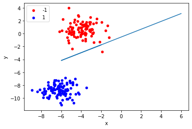

```
Iteration :  5  Weights :  [ 0.12066367 -0.13971455]  bais :  -0.09999999999999999
```

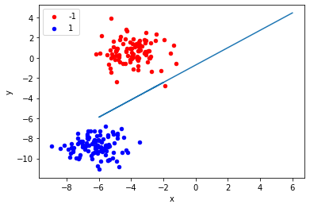

```
Iteration :  6  Weights :  [ 0.09236728 -0.19022382]  bais :  -0.10999999999999999
```

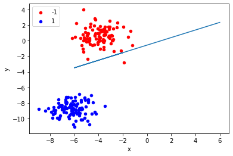

```
Iteration :  7  Weights :  [ 0.11136412 -0.16234187]  bais :  -0.11999999999999998
```

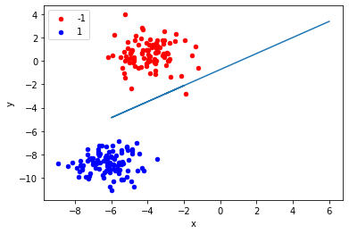

```
Iteration :  8  Weights :  [ 0.11423271 -0.18333985]  bais :  -0.12999999999999998
```

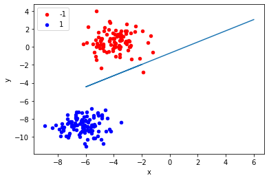

```
Iteration :  9  Weights :  [ 0.13322955 -0.15545789]  bais :  -0.13999999999999999
```

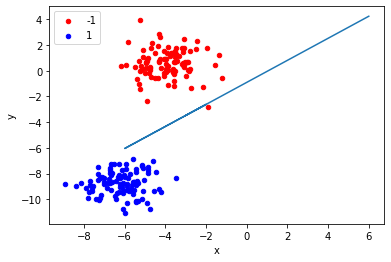

```
Iteration :  10  Weights :  [ 0.08341892 -0.21879772]  bais :  -0.13999999999999999
```

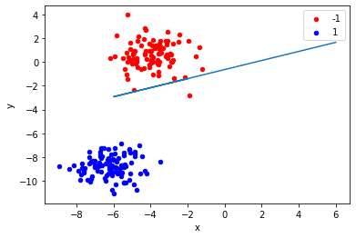

```
Iteration :  11  Weights :  [ 0.10241576 -0.19091577]  bais :  -0.15
```

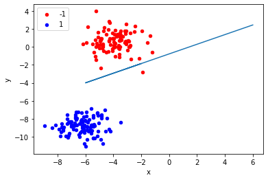

```
Iteration :  12  Weights :  [ 0.12141259 -0.16303381]  bais :  -0.16
```

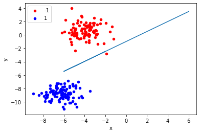

```
Iteration :  13  Weights :  [ 0.11807816 -0.19451643]  bais :  -0.17
```

[9 more figures not shown]

```
Iteration :  22  Weights :  [ 0.12415247 -0.16864032]  bais :  -0.24000000000000007
```

```
Iteration :  23  Weights :  [ 0.12415247 -0.16864032]  bais :  -0.24000000000000007
```

```
Iteration :  24  Weights :  [ 0.12415247 -0.16864032]  bais :  -0.24000000000000007
```

```
Iteration :  25  Weights :  [ 0.12415247 -0.16864032]  bais :  -0.24000000000000007
```

```
Iteration :  26  Weights :  [ 0.12415247 -0.16864032]  bais :  -0.24000000000000007
```

```
Iteration :  27  Weights :  [ 0.12415247 -0.16864032]  bais :  -0.24000000000000007
```

```
Iteration :  28  Weights :  [ 0.12415247 -0.16864032]  bais :  -0.24000000000000007
```

```
Iteration :  29  Weights :  [ 0.12415247 -0.16864032]  bais :  -0.24000000000000007
```

```
Iteration :  30  Weights :  [ 0.12415247 -0.16864032]  bais :  -0.24000000000000007
```

```
Iteration :  31  Weights :  [ 0.12415247 -0.16864032]  bais :  -0.24000000000000007
```

```
Iteration :  32  Weights :  [ 0.12415247 -0.16864032]  bais :  -0.24000000000000007
```

```
Iteration :  33  Weights :  [ 0.12415247 -0.16864032]  bais :  -0.24000000000000007
```

```
Iteration :  34  Weights :  [ 0.12415247 -0.16864032]  bais :  -0.24000000000000007
```

```
Iteration :  35  Weights :  [ 0.12415247 -0.16864032]  bais :  -0.24000000000000007
```

```
Iteration :  36  Weights :  [ 0.12415247 -0.16864032]  bais :  -0.24000000000000007
```

```
Iteration :  37  Weights :  [ 0.12415247 -0.16864032]  bais :  -0.24000000000000007
```

```
Iteration :  38  Weights :  [ 0.12415247 -0.16864032]  bais :  -0.24000000000000007
```

```
Iteration :  39  Weights :  [ 0.12415247 -0.16864032]  bais :  -0.24000000000000007
```

```
Iteration :  40  Weights :  [ 0.12415247 -0.16864032]  bais :  -0.24000000000000007
```

```
Iteration :  41  Weights :  [ 0.12415247 -0.16864032]  bais :  -0.24000000000000007
```

```
Iteration :  42  Weights :  [ 0.12415247 -0.16864032]  bais :  -0.24000000000000007
```

```
Iteration :  43  Weights :  [ 0.12415247 -0.16864032]  bais :  -0.24000000000000007
```

```
Iteration :  44  Weights :  [ 0.12415247 -0.16864032]  bais :  -0.24000000000000007
```

```
Iteration :  45  Weights :  [ 0.12415247 -0.16864032]  bais :  -0.24000000000000007
```

```
Iteration :  46  Weights :  [ 0.12415247 -0.16864032]  bais :  -0.24000000000000007
```

```
Iteration :  47  Weights :  [ 0.12415247 -0.16864032]  bais :  -0.24000000000000007
```

```
Iteration :  48  Weights :  [ 0.12415247 -0.16864032]  bais :  -0.24000000000000007
```

```
Iteration :  49  Weights :  [ 0.12415247 -0.16864032]  bais :  -0.24000000000000007
```

```
Iteration :  50  Weights :  [ 0.12415247 -0.16864032]  bais :  -0.24000000000000007
```

```
Iteration :  51  Weights :  [ 0.12415247 -0.16864032]  bais :  -0.24000000000000007
```

```
Iteration :  52  Weights :  [ 0.12415247 -0.16864032]  bais :  -0.24000000000000007
```

```
Iteration :  53  Weights :  [ 0.12415247 -0.16864032]  bais :  -0.24000000000000007
```

```
Iteration :  54  Weights :  [ 0.12415247 -0.16864032]  bais :  -0.24000000000000007
```

```
Iteration :  55  Weights :  [ 0.12415247 -0.16864032]  bais :  -0.24000000000000007
```

```
Iteration :  56  Weights :  [ 0.12415247 -0.16864032]  bais :  -0.24000000000000007
```

```
Iteration :  57  Weights :  [ 0.12415247 -0.16864032]  bais :  -0.24000000000000007
```

```
Iteration :  58  Weights :  [ 0.12415247 -0.16864032]  bais :  -0.24000000000000007
```

```
Iteration :  59  Weights :  [ 0.12415247 -0.16864032]  bais :  -0.24000000000000007
```

```
Iteration :  60  Weights :  [ 0.12415247 -0.16864032]  bais :  -0.24000000000000007
```

```
Iteration :  61  Weights :  [ 0.12415247 -0.16864032]  bais :  -0.24000000000000007
```

```
Iteration :  62  Weights :  [ 0.12415247 -0.16864032]  bais :  -0.24000000000000007
```

```
Iteration :  63  Weights :  [ 0.12415247 -0.16864032]  bais :  -0.24000000000000007
```

```
Iteration :  64  Weights :  [ 0.12415247 -0.16864032]  bais :  -0.24000000000000007
```

```
Iteration :  65  Weights :  [ 0.12415247 -0.16864032]  bais :  -0.24000000000000007
```

```
Iteration :  66  Weights :  [ 0.12415247 -0.16864032]  bais :  -0.24000000000000007
```

```
Iteration :  67  Weights :  [ 0.12415247 -0.16864032]  bais :  -0.24000000000000007
```

```
Iteration :  68  Weights :  [ 0.12415247 -0.16864032]  bais :  -0.24000000000000007
```

```
Iteration :  69  Weights :  [ 0.12415247 -0.16864032]  bais :  -0.24000000000000007
```

```
Iteration :  70  Weights :  [ 0.12415247 -0.16864032]  bais :  -0.24000000000000007
```

```
Iteration :  71  Weights :  [ 0.12415247 -0.16864032]  bais :  -0.24000000000000007
```

```
Iteration :  72  Weights :  [ 0.12415247 -0.16864032]  bais :  -0.24000000000000007
```

```
Iteration :  73  Weights :  [ 0.12415247 -0.16864032]  bais :  -0.24000000000000007
```

```
Iteration :  74  Weights :  [ 0.12415247 -0.16864032]  bais :  -0.24000000000000007
```

```
Iteration :  75  Weights :  [ 0.12415247 -0.16864032]  bais :  -0.24000000000000007
```

```
Iteration :  76  Weights :  [ 0.12415247 -0.16864032]  bais :  -0.24000000000000007
```

```
Iteration :  77  Weights :  [ 0.12415247 -0.16864032]  bais :  -0.24000000000000007
```

```
Iteration :  78  Weights :  [ 0.12415247 -0.16864032]  bais :  -0.24000000000000007
```

```
Iteration :  79  Weights :  [ 0.12415247 -0.16864032]  bais :  -0.24000000000000007
```

```
Iteration :  80  Weights :  [ 0.12415247 -0.16864032]  bais :  -0.24000000000000007
```

```
Iteration :  81  Weights :  [ 0.12415247 -0.16864032]  bais :  -0.24000000000000007
```

```
Iteration :  82  Weights :  [ 0.12415247 -0.16864032]  bais :  -0.24000000000000007
```

```
Iteration :  83  Weights :  [ 0.12415247 -0.16864032]  bais :  -0.24000000000000007
```

```
Iteration :  84  Weights :  [ 0.12415247 -0.16864032]  bais :  -0.24000000000000007
```

```
Iteration :  85  Weights :  [ 0.12415247 -0.16864032]  bais :  -0.24000000000000007
```

```
Iteration :  86  Weights :  [ 0.12415247 -0.16864032]  bais :  -0.24000000000000007
```

```
Iteration :  87  Weights :  [ 0.12415247 -0.16864032]  bais :  -0.24000000000000007
```

```
Iteration :  88  Weights :  [ 0.12415247 -0.16864032]  bais :  -0.24000000000000007
```

```
Iteration :  89  Weights :  [ 0.12415247 -0.16864032]  bais :  -0.24000000000000007
```

```
Iteration :  90  Weights :  [ 0.12415247 -0.16864032]  bais :  -0.24000000000000007
```

```
Iteration :  91  Weights :  [ 0.12415247 -0.16864032]  bais :  -0.24000000000000007
```

```
Iteration :  92  Weights :  [ 0.12415247 -0.16864032]  bais :  -0.24000000000000007
```

```
Iteration :  93  Weights :  [ 0.12415247 -0.16864032]  bais :  -0.24000000000000007
```

```
Iteration :  94  Weights :  [ 0.12415247 -0.16864032]  bais :  -0.24000000000000007
```

```
Iteration :  95  Weights :  [ 0.12415247 -0.16864032]  bais :  -0.24000000000000007
```

```
Iteration :  96  Weights :  [ 0.12415247 -0.16864032]  bais :  -0.24000000000000007
```

```
Iteration :  97  Weights :  [ 0.12415247 -0.16864032]  bais :  -0.24000000000000007
```

```
Iteration :  98  Weights :  [ 0.12415247 -0.16864032]  bais :  -0.24000000000000007
```

```
Iteration :  99  Weights :  [ 0.12415247 -0.16864032]  bais :  -0.24000000000000007
```

```
Iteration :  100  Weights :  [ 0.12415247 -0.16864032]  bais :  -0.24000000000000007
```

```python
X = df_Linear1.values
y = X[:,-1]
X = X[:,:2]
learning_rate = 0.01
weight = np.zeros(2)
bais = 0

weight,bais = perceptron(df_Linear1,X,y,weight,bais,6,100)
# i =19
# print(predict(X[i],weight,bais))
# print(y[i])
```

# Non-Linear dataset

## Random dataset

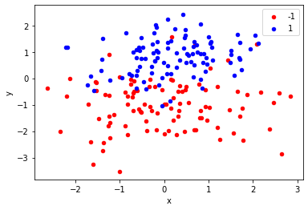

```python
X,y = sklearn.datasets.samples_generator.make_classification(n_samples=200, n_features=2, n_informative=1,
                        n_redundant=0, n_repeated=0, n_classes=2,
                        n_clusters_per_class=1, weights=None, flip_y=0.01,
                        class_sep=1.0, hypercube=True, shift=0.0, scale=1.0,
                        shuffle=True, random_state=22)
y[y==0] = -1
df_Non_Linear = pd.DataFrame(dict(x=X[:,0], y=X[:,1], label=y))
# df.to_csv('./dataset/nonLinearDataset.csv',sep="\t",index=None)
#df = pd.read_csv('./dataset/nonLinearDataset.csv',sep='\t')

colors = {-1:'red', 1:'blue'}
fig, ax = plt.subplots()
grouped = df_Non_Linear.groupby('label')

for key, group in grouped:
    group.plot(ax=ax, kind='scatter', x='x', y='y', label=key, color=colors[key])
plt.show()
```

```
Iteration :  1  Weights :  [0.00666673 0.0568991 ]  bais :  0.0
```

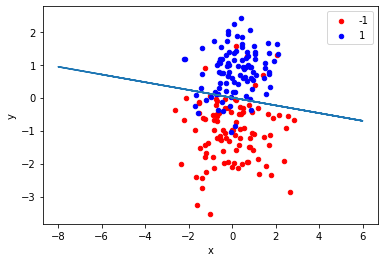

```
Iteration :  2  Weights :  [0.00787005 0.05235648]  bais :  0.0
```

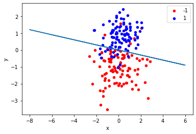

```
Iteration :  3  Weights :  [0.00439058 0.04292798]  bais :  -0.01
```

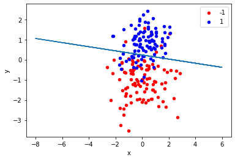

```
Iteration :  4  Weights :  [0.00749727 0.03752111]  bais :  0.0
```

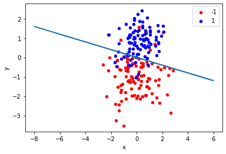

```
Iteration :  5  Weights :  [0.00629699 0.04263231]  bais :  0.0
```

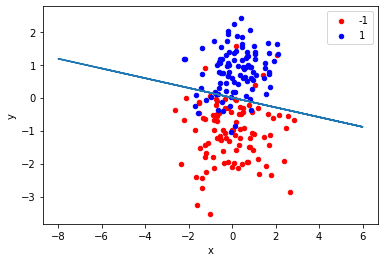

```
Iteration :  6  Weights :  [0.00699296 0.03666931]  bais :  0.0
```

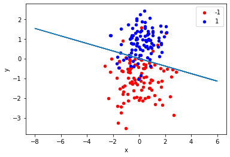

```
Iteration :  7  Weights :  [0.00936869 0.03699742]  bais :  0.0
```

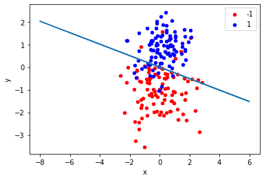

```
Iteration :  8  Weights :  [0.00122337 0.05002479]  bais :  0.0
```

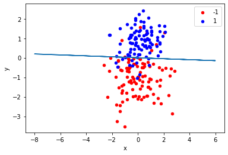

```
Iteration :  9  Weights :  [0.00083716 0.03973738]  bais :  0.0
```

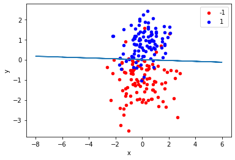

```
Iteration :  10  Weights :  [0.00754671 0.05599994]  bais :  0.0
```

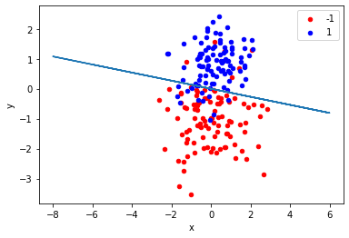

```python
X = df_Non_Linear.values
y = X[:,-1]
X = X[:,:2]
learning_rate = 0.01
weight = np.zeros(2)
bais = 0

weight,bais = perceptron(df_Non_Linear,X,y,weight,bais,8)
# i =19
# print(predict(X[i],weight,bais))
# print(y[i])
```